# Crime in Los Angeles from 2010-2019

#####4.2.2 Lasso Regression  
The lasso regression will also penalize the coefficients. Lasso regression will drop features which are not useful to improve prediction accuracy.

```
glmnet

80001 samples
   67 predictor

No pre-processing
Resampling: Cross-Validated (10 fold, repeated 5 times)
Summary of sample sizes: 72001, 72001, 71999, 72001, 72002, 72000, ...
Resampling results across tuning parameters:

  lambda    RMSE      Rsquared   MAE
  0.000100  14.83723  0.1396451  12.09405
  0.012575  14.83718  0.1396506  12.09663
  0.025050  14.83808  0.1395655  12.10111
  0.037525  14.83989  0.1393924  12.10631
  0.050000  14.84239  0.1391539  12.11195

Tuning parameter 'alpha' was held constant at a value of 1
RMSE was used to select the optimal model using the smallest value.
The final values used for the model were alpha = 1 and lambda = 0.012575.
```

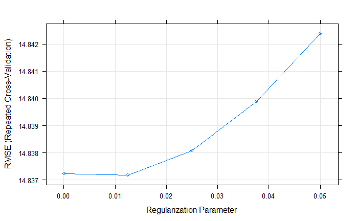

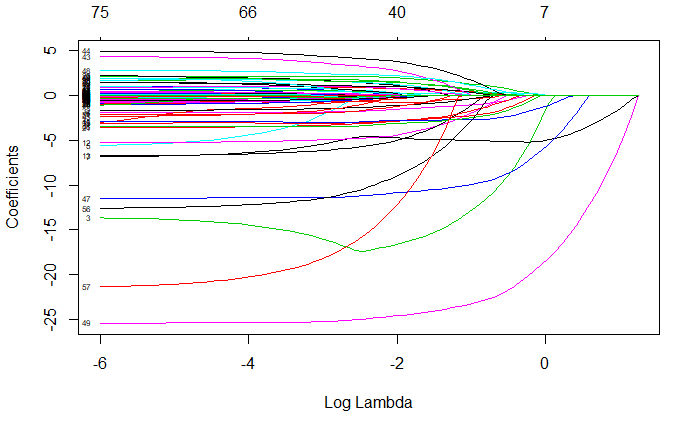

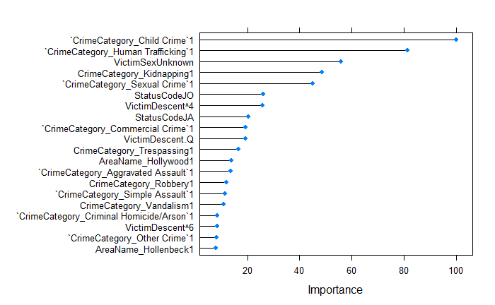

#####4.2.3 Elastic-Net Regression  
Elastic-Net regression combines Ridge and Lasso regression penalties to generate a better model.

|  | alpha | lambda |
| --- | --- | --- |
| 36 | 0.3333333 | 0.02782222 |

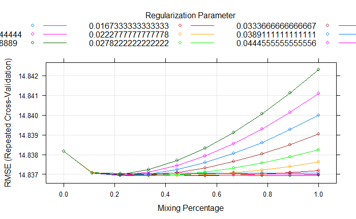

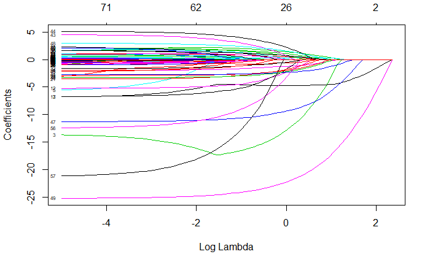

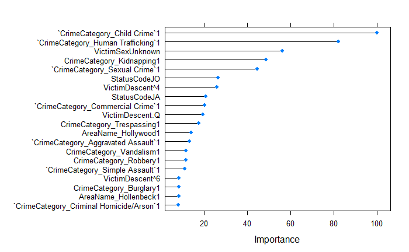

#####4.2.4 Compare Models

```
Call:
summary.resamples(object = compare)

Models: Ridge, Lasso, ElasticNet
Number of resamples: 50

MAE
               Min.  1st Qu.   Median     Mean  3rd Qu.     Max. NA's
Ridge      11.94764 12.07110 12.09526 12.09904 12.14661 12.25540    0
Lasso      11.94213 12.05104 12.09301 12.09663 12.15097 12.24088    0
ElasticNet 11.94599 12.06724 12.09205 12.09580 12.14277 12.25192    0

RMSE
               Min.  1st Qu.   Median     Mean  3rd Qu.     Max. NA's
Ridge      14.61253 14.78422 14.83954 14.83816 14.89755 15.10775    0
Lasso      14.65369 14.76972 14.84976 14.83718 14.90065 15.02511    0
ElasticNet 14.61361 14.78196 14.83801 14.83693 14.89526 15.10645    0

Rsquared
                Min.   1st Qu.    Median      Mean   3rd Qu.      Max. NA's
Ridge      0.1191597 0.1349742 0.1402232 0.1395412 0.1448331 0.1551684    0
Lasso      0.1269149 0.1354689 0.1379484 0.1396506 0.1425351 0.1595355    0
ElasticNet 0.1191377 0.1350267 0.1403649 0.1396666 0.1449210 0.1552539    0
```

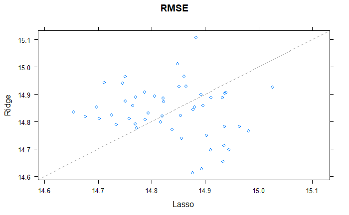

We can find from the summary, the RMSE for Elastic-Net regresstion is the smallest, and Rsquared is the largest for Elastic-Net regression which means the model can explain more of the information than another two models. Therefore, the ElasticNet Model should be used to predict the victim age after comparison.  
In the chart, Ridge regression has a higher RMSE if the point lies above the dotted line and Lasso has a higher RMSE if the point lies below the dotted line.

####4.3 Decision Tree  
The decision tree model is used to classify the **Victim Race** under specific conditions.

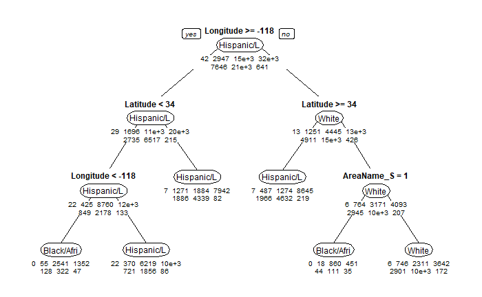

The model has chosen Longitude as root node. For example, from the above decision tree, it can be inferred that if Longitude < -118 and Latitude >= 34, then the Victim will be a Hispanic/Latino.  
In a similar way, we can interpret the victim race in other nodes.

####4.4 Forecasting - Arima

```r
la.ts <- window(lacrime.ts,start=2010, end=c(2018,12))
summary(ur.kpss(la.ts))
```

```
#######################
# KPSS Unit Root Test #
#######################

Test is of type: mu with 4 lags.

Value of test-statistic is: 1.1626

Critical value for a significance level of:
                10pct  5pct 2.5pct  1pct
critical values 0.347 0.463  0.574 0.739
```

```r
ndiffs(la.ts)
```

```
[1] 1
```

```r
la.ts %>% diff() %>% ur.kpss() %>% summary()
```

```
#######################
# KPSS Unit Root Test #
#######################

Test is of type: mu with 4 lags.

Value of test-statistic is: 0.0978

Critical value for a significance level of:
                10pct  5pct 2.5pct  1pct
critical values 0.347 0.463  0.574 0.739
```

Without differencing, test-statistic > critical value (5pct), we reject the null hypothsis (data is stationary). As for ARIMA forecasting, the data should be stationary, so I checked there should be one difference to make the data stationary. After taking fisrt difference, test-statistic < critical value (5pct), so we do not reject null hypothesis (data is stationary).

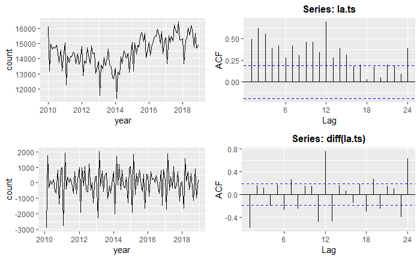

The data is stationary after taken one differencing as we can see from the charts above.

```
Series: la.ts
ARIMA(2,1,0)

Coefficients:
          ar1      ar2
      -0.8357  -0.3378
s.e.   0.0933   0.0946

sigma^2 estimated as 560879:  log likelihood=-859.38
AIC=1724.76   AICc=1724.99   BIC=1732.78

Training set error measures:
                    ME     RMSE      MAE        MPE     MAPE     MASE       ACF1
Training set -10.51238 738.4436 570.4777 -0.2833682 4.055911 1.035624 0.07250835
Series: la.ts
ARIMA(0,1,1)(0,1,1)[12]

Coefficients:
          ma1    sma1
      -0.4770  -0.617
s.e.   0.0983   0.130

sigma^2 estimated as 171847:  log likelihood=-709.36
AIC=1424.73   AICc=1424.99   BIC=1432.39

Training set error measures:
                  ME     RMSE      MAE       MPE     MAPE      MASE       ACF1
Training set 37.9805 384.6812 302.8642 0.2552095 2.107092 0.5498082 0.01883237

    Ljung-Box test

data:  Residuals from ARIMA(0,1,1)(0,1,1)[12]
Q* = 16.437, df = 20, p-value = 0.6892

Model df: 2.   Total lags used: 22
```

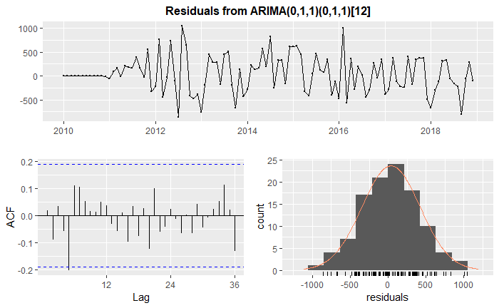

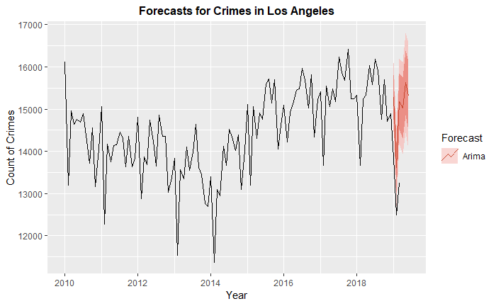

The first model ARIMA(2,1,0) was selected automatically, RMSE = 738.4436, AICc = 1724.99. The second model ARIMA(0,1,1)(0,1,1)[12] is selected by running all the combination, RMSE = 384.6812, AICc = 1424.99. AICc and RMSE of **ARIMA(0,1,1)(0,1,1)[12]** are much less than ARIMA(2,1,0), so the second model is better than the first one.  
The residuals should be normal distributed, without variance, and without autocorrelation which we can observed from the graph Residuals from ARIMA(0,1,1)(0,1,1)[12].  
The trend of the crimes committed in the first 6 months of 2019 in Los Angeles is represented in the second graph above.  
The predicted numbers of the crimes of the first 6 months of 2019 are shown below:

|  | Months | Predictions |
| --- | --- | --- |
| 1 | Jan 2019 | 15282 |
| 2 | Feb 2019 | 13615 |
| 3 | Mar 2019 | 15182 |
| 4 | Apr 2019 | 15027 |
| 5 | May 2019 | 15622 |
| 6 | Jun 2019 | 15310 |

###5. Shiny App  
You can use the Shiny App to see interactive outputs.